# Mammal data - Planted Conifer Forests

Talia Gabay & Ron Chen

2025-11-11

## Planted Conifer Forests - Richness by camera

### There are 15 sites total, each site has 5 sampling points

Let’s first validate the data:

```
## [1] "Settlements has 1 level"
```

```
## [1] "Far"
```

```
## [1] "Subunit has 3 levels"
```

```
## [1] "Carmel"  "Galilee" "Judea"
```

```
## [1] "Site has 15 levels"
```

```
##  [1] "Aderet"          "Amatzia"         "Bat Shlomo"      "Eitanim"
##  [5] "Elyakim"         "Eshtaol"         "Givat Yeshayahu" "Kabri"
##  [9] "Kerem Maharal"   "Manara"          "Meron"           "Ofer"
## [13] "Ramat Hashofet"  "Ramot Naftali"   "Zuriel"
```

```
## [1] "Transect has 15 levels"
```

```
##  [1] "Aderet Far"          "Amatzia Far"         "Bat Shlomo Far"
##  [4] "Eitanim Far"         "Elyakim Far"         "Eshtaol Far"
##  [7] "Givat Yeshayahu Far" "Kabri Far"           "Kerem Maharal Far"
## [10] "Manara Far"          "Meron Far"           "Ofer Far"
## [13] "Ramat Hashofet Far"  "Ramot Naftali Far"   "Zuriel Far"
```

```
## [1] "Transect with date has 75 levels"
```

```
##  [1] "Aderet Far_02_06_2013"          "Aderet Far_16_10_2021"
##  [3] "Aderet Far_21_08_2017"          "Aderet Far_24_05_2015"
##  [5] "Aderet Far_28_10_2019"          "Amatzia Far_02_06_2013"
##  [7] "Amatzia Far_04_12_2021"         "Amatzia Far_12_02_2018"
##  [9] "Amatzia Far_17_12_2019"         "Amatzia Far_24_05_2015"
## [11] "Bat Shlomo Far_18_11_2017"      "Bat Shlomo Far_21_08_2021"
## [13] "Bat Shlomo Far_28_06_2015"      "Bat Shlomo Far_30_06_2013"
## [15] "Bat Shlomo Far_30_11_2019"      "Eitanim Far_01_10_2017"
## [17] "Eitanim Far_08_10_2021"         "Eitanim Far_09_06_2015"
## [19] "Eitanim Far_09_11_2019"         "Eitanim Far_17_06_2013"
## [21] "Elyakim Far_04_09_2021"         "Elyakim Far_06_09_2015"
## [23] "Elyakim Far_07_11_2017"         "Elyakim Far_16_02_2020"
## [25] "Elyakim Far_30_06_2013"         "Eshtaol Far_01_12_2019"
## [27] "Eshtaol Far_07_06_2015"         "Eshtaol Far_17_06_2013"
## [29] "Eshtaol Far_22_10_2017"         "Eshtaol Far_22_10_2021"
```

[output cut: 23 more lines]

```
## [1] "RICHNESS WITH RARE SPECIES"
```

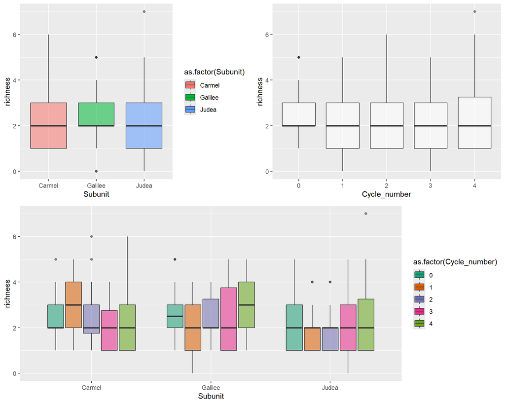

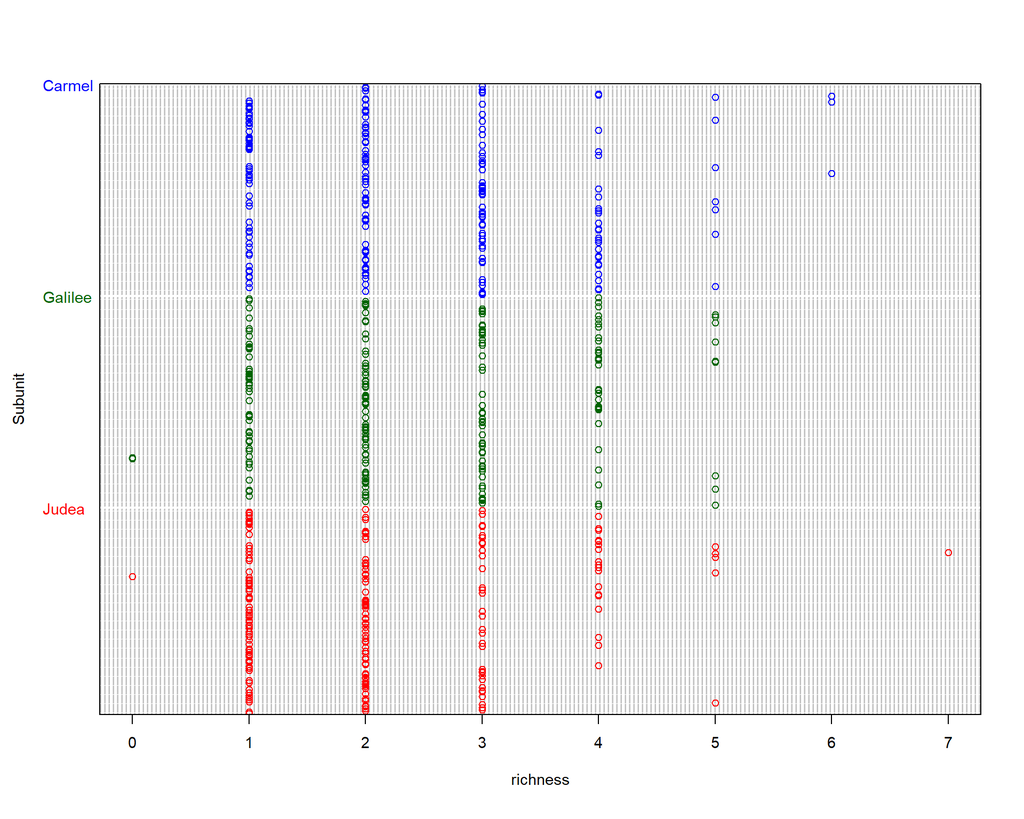

Explore abundances:

```
##    Canis aureus     Canis lupus   Capra nubiana  Equus hemionus  Gazella dorcas
##            1350              85               0               0               0
## Gazella gazella   Hyaena hyaena  Hystrix indica  Lepus capensis     Meles meles
##             671              43             655              27              74
##   Oryx leucoryx      Sus scrofa   Vulpes vulpes
##               0            2025             683
```

```
## Overlapping points were shifted along the y-axis to make them visible.
```

```
##
##  PIPING TO 2nd MVFACTOR
```

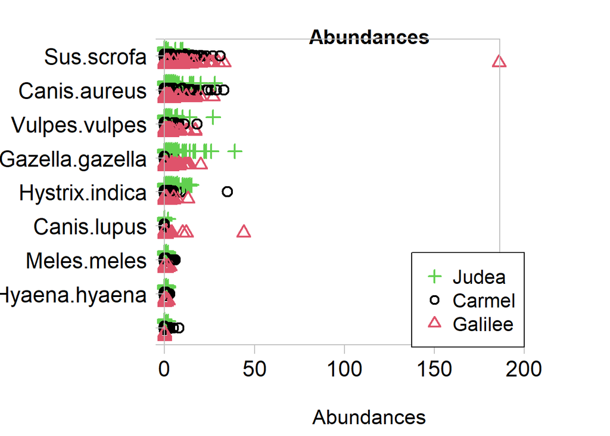

Sus scrofa only:

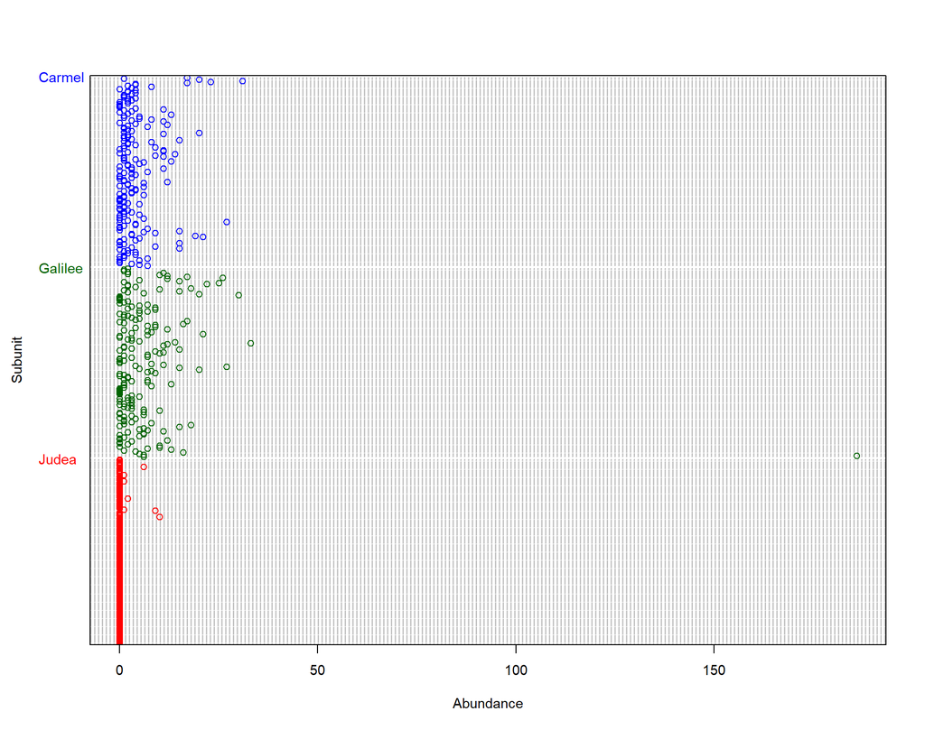

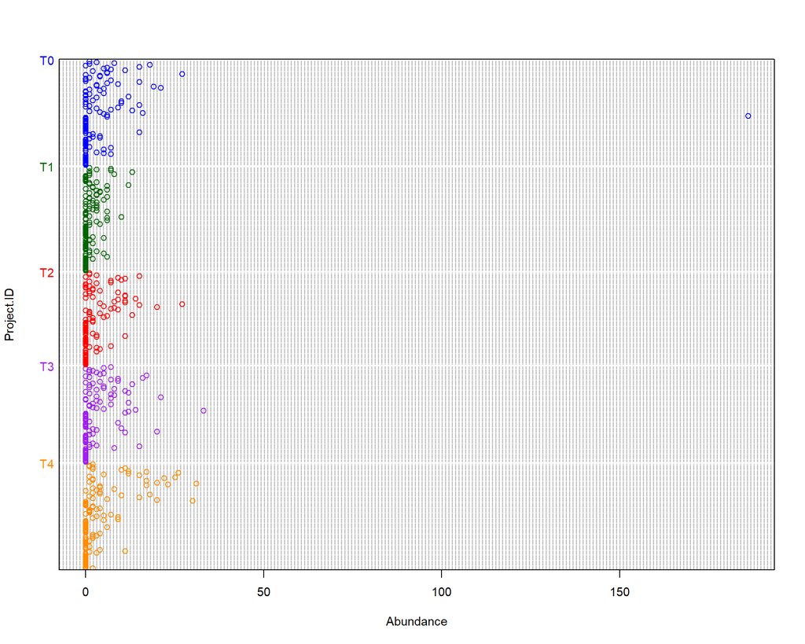

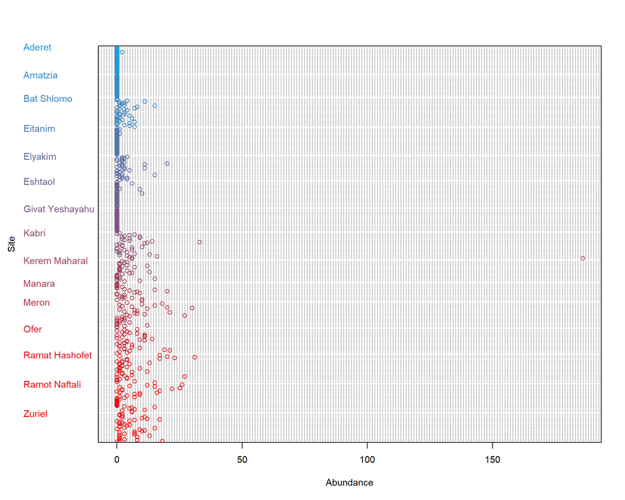

Fix outlier observation of 186 wild boar, by setting the count to be equal to the highest count observed.

```
## Overlapping points were shifted along the y-axis to make them visible.
```

```
##
##  PIPING TO 2nd MVFACTOR
```

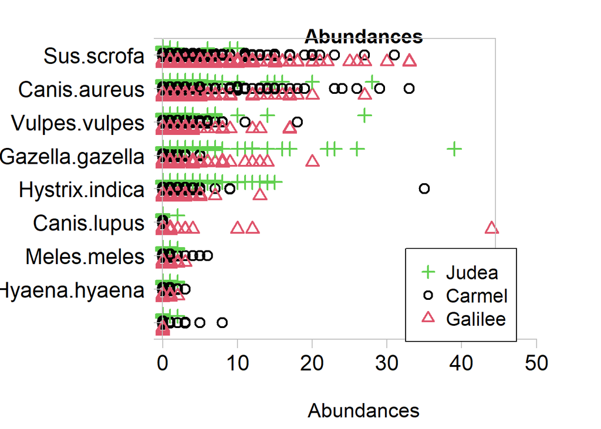

Fix outlier observations of canis lupus, gazella gazella and hystrix indica, by setting the count to be equal to the highest count observed for the species.

```
## Overlapping points were shifted along the y-axis to make them visible.
```

```
##
##  PIPING TO 2nd MVFACTOR
```

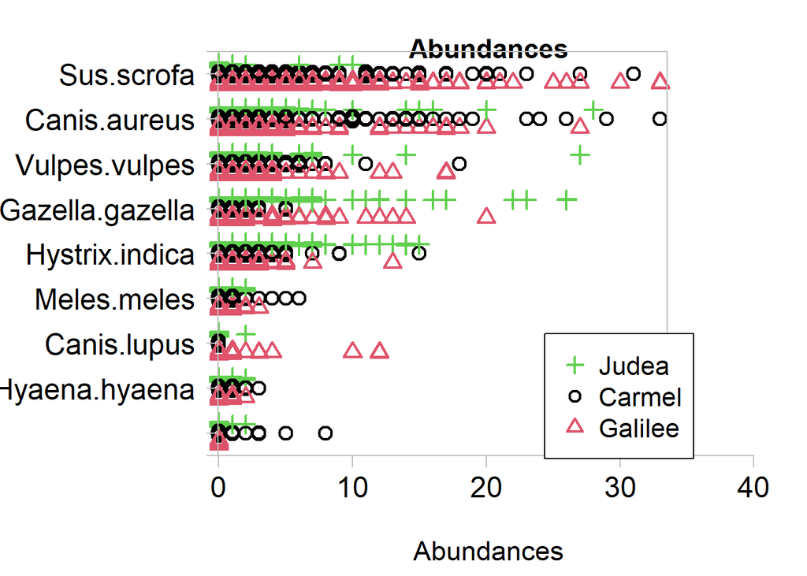

|  | richness | abundance | Subunit | rescaled_Time.Diff | cosinus_Monitoring.Time.Diff | sinus_Monitoring.Time.Diff | Site | Transect | Transect_with_date | Distance_rescaled |
| --- | --- | --- | --- | --- | --- | --- | --- | --- | --- | --- |
|  | Min. :0.000 | Min. : 0.00 | Carmel :185 | Min. :-1.5480 | Min. :-0.99750 | Min. :-0.99061 | Bat Shlomo : 42 | Bat Shlomo Far : 42 | Bat Shlomo Far_28_06_2015 : 10 | Min. :-0.86297 |
|  | 1st Qu.:1.000 | 1st Qu.: 3.00 | Galilee:185 | 1st Qu.:-0.9164 | 1st Qu.:-0.83907 | 1st Qu.:-0.64354 | Zuriel : 42 | Zuriel Far : 42 | Bat Shlomo Far_30_06_2013 : 10 | 1st Qu.:-0.23014 |
|  | Median :2.000 | Median : 6.00 | Judea :181 | Median :-0.1491 | Median : 0.10159 | Median : 0.07072 | Ramat Hashofet: 41 | Ramat Hashofet Far: 41 | Kabri Far_09_08_2015 : 10 | Median : 0.04593 |
|  | Mean :2.334 | Mean : 10.19 | NA | Mean :-0.2012 | Mean :-0.01326 | Mean : 0.01837 | Ramot Naftali : 41 | Ramot Naftali Far : 41 | Ofer Far_16_06_2013 : 10 | Mean : 0.12773 |
|  | 3rd Qu.:3.000 | 3rd Qu.: 13.00 | NA | 3rd Qu.: 0.5379 | 3rd Qu.: 0.71796 | 3rd Qu.: 0.69608 | Aderet : 39 | Aderet Far : 39 | Ramat Hashofet Far_01_07_2013: 10 | 3rd Qu.: 0.31041 |
|  | Max. :7.000 | Max. :207.00 | NA | Max. : 1.1366 | Max. : 0.99859 | Max. : 0.99952 | Eitanim : 39 | Eitanim Far : 39 | Aderet Far_16_10_2021 : 9 | Max. : 1.86789 |
|  | NA | NA | NA | NA | NA | NA | (Other) :307 | (Other) :307 | (Other) :492 | NA |

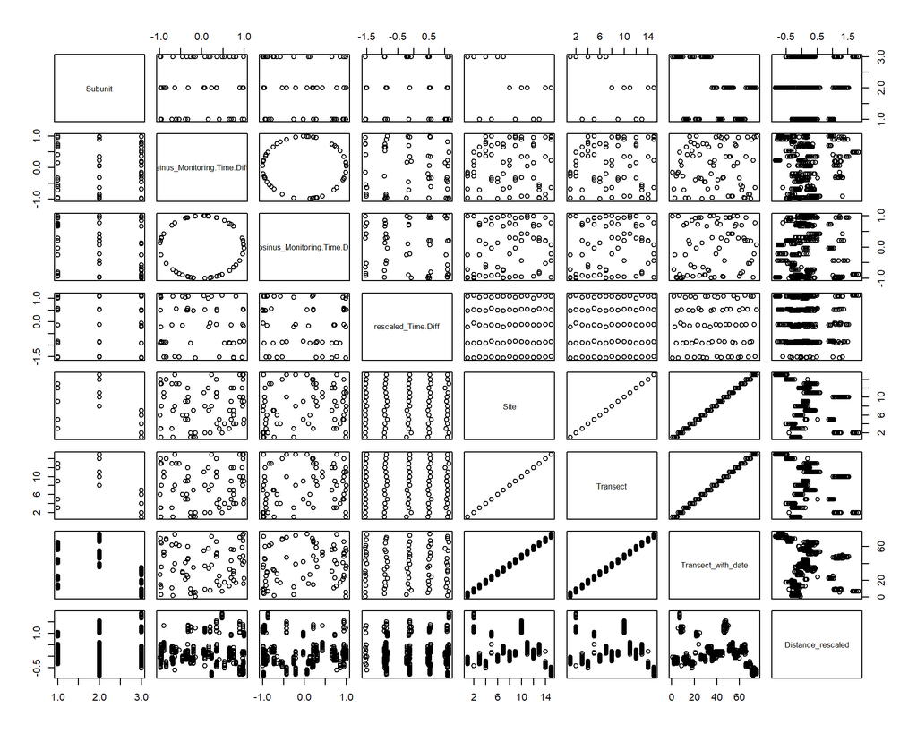

|  | Subunit | sinus_Monitoring.Time.Diff | cosinus_Monitoring.Time.Diff | rescaled_Time.Diff | Site | Transect | Transect_with_date | Distance_rescaled |
| --- | --- | --- | --- | --- | --- | --- | --- | --- |
| Subunit | 1.0000000 | 0.0269857 | -0.2929366 | 0.0722343 | -0.3990533 | -0.3990533 | -0.3976850 | -0.0426536 |
| sinus_Monitoring.Time.Diff | 0.0269857 | 1.0000000 | 0.0004384 | -0.1194839 | 0.0164255 | 0.0164255 | 0.0072200 | 0.0290773 |
| cosinus_Monitoring.Time.Diff | -0.2929366 | 0.0004384 | 1.0000000 | -0.1073206 | 0.1899325 | 0.1899325 | 0.1723042 | 0.0083534 |
| rescaled_Time.Diff | 0.0722343 | -0.1194839 | -0.1073206 | 1.0000000 | -0.0131054 | -0.0131054 | -0.0115445 | -0.0524663 |
| Site | -0.3990533 | 0.0164255 | 0.1899325 | -0.0131054 | 1.0000000 | 1.0000000 | 0.9979562 | -0.2302542 |
| Transect | -0.3990533 | 0.0164255 | 0.1899325 | -0.0131054 | 1.0000000 | 1.0000000 | 0.9979562 | -0.2302542 |
| Transect_with_date | -0.3976850 | 0.0072200 | 0.1723042 | -0.0115445 | 0.9979562 | 0.9979562 | 1.0000000 | -0.2313637 |
| Distance_rescaled | -0.0426536 | 0.0290773 | 0.0083534 | -0.0524663 | -0.2302542 | -0.2302542 | -0.2313637 | 1.0000000 |

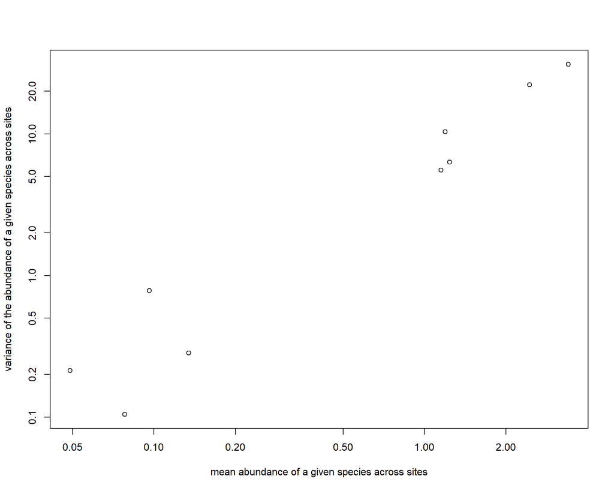

#### Community analysis using package MVabund

Table of abundances per species by camera ID

```
## [1] 551  14
```

```
## [1] 279
```

```
## [1] 13
```

```
## [1] 0
```

```
## [1] 0
```

```
## [1] 0
```

```
## [1] 145
```

```
## [1] 35
```

```
## [1] 201
```

```
## [1] 10
```

```
## [1] 49
```

```
## [1] 0
```

```
## [1] 301
```

```
## [1] 253
```

```
##    Canis aureus     Canis lupus   Capra nubiana  Equus hemionus  Gazella dorcas
##            1350              53               0               0               0
## Gazella gazella   Hyaena hyaena  Hystrix indica  Lepus capensis     Meles meles
##             658              43             635              27              74
##   Oryx leucoryx      Sus scrofa   Vulpes vulpes
##               0            1872             683
```

```
##    Canis.aureus     Canis.lupus Gazella.gazella   Hyaena.hyaena  Hystrix.indica
##            1350              53             658              43             635
##  Lepus.capensis     Meles.meles      Sus.scrofa   Vulpes.vulpes
##              27              74            1872             683
```

Species with 20 individuals or more - Canis aureus, Canis lupus, Gazella gazella, Hyaena hyaena, Hystrix indica, Lepus capensis, Meles meles, Sus scorfa and Vulpus vulpus

Left with 9 species

```
##       nb       po
## 1073.793 1711.534
```

```
## [1] "POISSON"
```

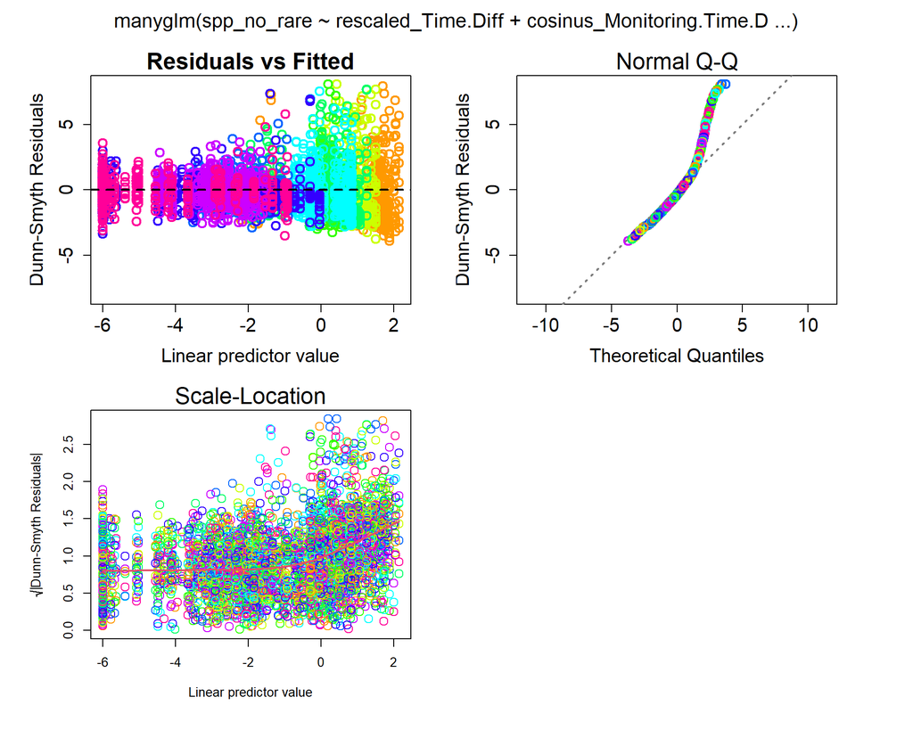

```
## [1] "NEGATIVE BINOMIAL"
```

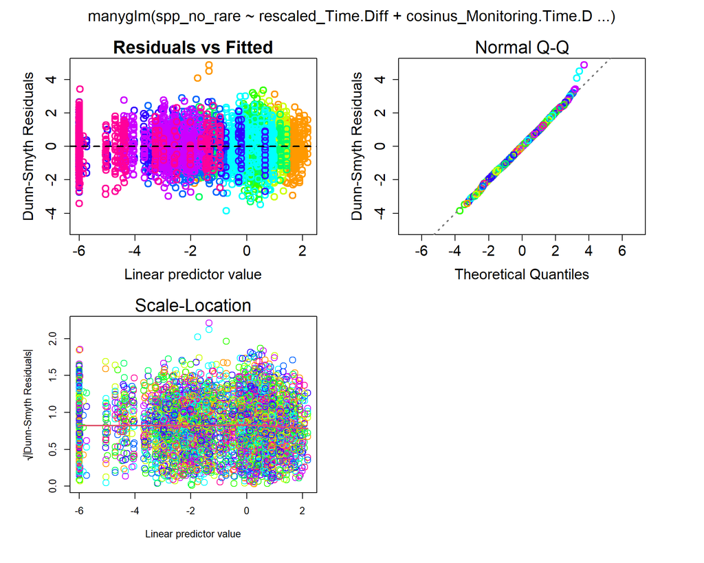

prefer negative binomial because standardized residuals are smaller.

```
##       nb       po      nb1
## 1073.793 1711.534 1113.120
```

```
##       nb       po      nb1      nb2
## 1073.793 1711.534 1113.120 1030.756
```

```
##       nb       po      nb1      nb2      nb3
## 1073.793 1711.534 1113.120 1030.756 1030.756
```

```
##       nb       po      nb1      nb2      nb3      nb4
## 1073.793 1711.534 1113.120 1030.756 1030.756 1030.756
```

```
##       nb       po      nb1      nb2      nb3      nb4      nb5
## 1073.793 1711.534 1113.120 1030.756 1030.756 1030.756 1030.756
```

Transect, Site and Subunit improve the model. Will proceed with Subunit:

## Many GLM with Sub-unit - no interactions

```
## Single term deletions
##
## Model:
## spp_no_rare ~ rescaled_Time.Diff + cosinus_Monitoring.Time.Diff +
##     sinus_Monitoring.Time.Diff + Subunit
##                              Df     AIC
## <none>                           9664.1
## rescaled_Time.Diff            9  9670.2
## cosinus_Monitoring.Time.Diff  9  9685.0
## sinus_Monitoring.Time.Diff    9  9664.6
## Subunit                      18 10018.1
```

Drop sine

```
## Single term deletions
##
## Model:
## spp_no_rare ~ rescaled_Time.Diff + cosinus_Monitoring.Time.Diff +
##     Subunit
##                              Df     AIC
## <none>                           9664.6
## rescaled_Time.Diff            9  9674.7
## cosinus_Monitoring.Time.Diff  9  9687.5
## Subunit                      18 10019.4
```

Final model includes Sub-unit, cosin and time

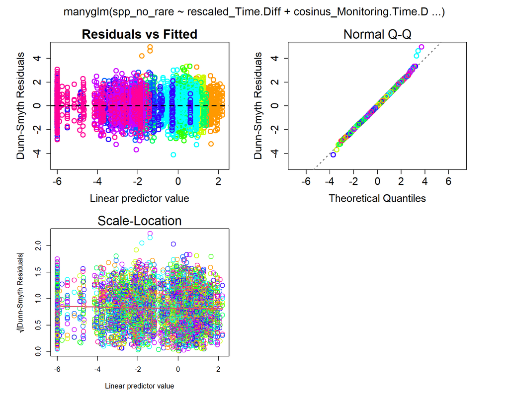

```
##
## Test statistics:
##                              wald value Pr(>wald)
## (Intercept)                      21.318     0.001 ***
## rescaled_Time.Diff                5.034     0.015 *
## cosinus_Monitoring.Time.Diff      6.370     0.001 ***
## SubunitGalilee                    6.610     0.001 ***
## SubunitJudea                     16.740     0.001 ***
## ---
## Signif. codes:  0 '***' 0.001 '**' 0.01 '*' 0.05 '.' 0.1 ' ' 1
##
## Test statistic:  20.82, p-value: 0.001
## Arguments:
##  Test statistics calculated assuming response assumed to be uncorrelated
##  P-value calculated using 999 resampling iterations via pit.trap resampling (to account for correlation in testing).
```

```
## Analysis of Deviance Table
##
## Model: spp_no_rare ~ rescaled_Time.Diff + cosinus_Monitoring.Time.Diff + Subunit
##
## Multivariate test:
##                              Res.Df Df.diff   Dev Pr(>Dev)
## (Intercept)                     550
## rescaled_Time.Diff              549       1  19.3    0.029 *
## cosinus_Monitoring.Time.Diff    548       1  57.3    0.001 ***
## Subunit                         546       2 390.8    0.001 ***
## ---
## Signif. codes:  0 '***' 0.001 '**' 0.01 '*' 0.05 '.' 0.1 ' ' 1
##
## Univariate Tests:
##                              Canis.aureus          Canis.lupus
##                                       Dev Pr(>Dev)         Dev Pr(>Dev)
## (Intercept)
## rescaled_Time.Diff                  3.308    0.441       1.662    0.663
## cosinus_Monitoring.Time.Diff        0.659    0.803      10.822    0.015
## Subunit                             7.977    0.075      22.196    0.001
##                              Gazella.gazella          Hyaena.hyaena
##                                          Dev Pr(>Dev)           Dev Pr(>Dev)
## (Intercept)
## rescaled_Time.Diff                     0.504    0.727         5.571    0.156
## cosinus_Monitoring.Time.Diff           0.112    0.932         0.007    0.943
## Subunit                               48.317    0.001         5.972    0.133
##                              Hystrix.indica          Lepus.capensis
##                                         Dev Pr(>Dev)            Dev Pr(>Dev)
## (Intercept)
## rescaled_Time.Diff                    1.121    0.727          0.886    0.727
## cosinus_Monitoring.Time.Diff          8.583    0.036          6.387    0.105
## Subunit                              31.449    0.001         10.968    0.031
##                              Meles.meles          Sus.scrofa
##                                      Dev Pr(>Dev)        Dev Pr(>Dev)
## (Intercept)
## rescaled_Time.Diff                 0.824    0.727      3.436    0.441
## cosinus_Monitoring.Time.Diff       2.586    0.424     25.244    0.001
## Subunit                            8.647    0.061    254.523    0.001
##                              Vulpes.vulpes
##                                        Dev Pr(>Dev)
## (Intercept)
## rescaled_Time.Diff                   1.989    0.643
## cosinus_Monitoring.Time.Diff         2.854    0.424
## Subunit                              0.779    0.734
## Arguments:
##  Test statistics calculated assuming uncorrelated response (for faster computation)
## P-value calculated using 999 iterations via PIT-trap resampling.
```

**Multivariate test shows that Sub-unit, cosin time of sampling and time affect species composition** **However time variable is not significant for any of the species. Therefore re-run without time variable.**

```
## Single term deletions
##
## Model:
## spp_no_rare ~ cosinus_Monitoring.Time.Diff + Subunit
##                              Df     AIC
## <none>                           9674.7
## cosinus_Monitoring.Time.Diff  9  9698.2
## Subunit                      18 10019.8
```

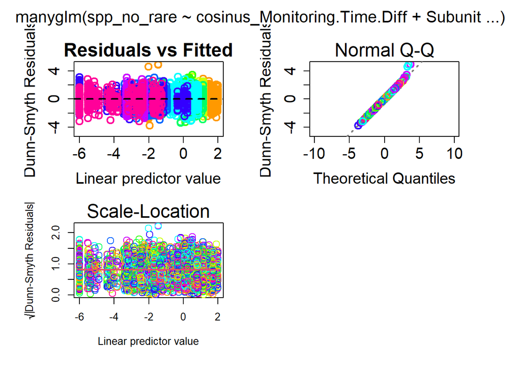

```
##
## Test statistics:
##                              wald value Pr(>wald)
## (Intercept)                      21.216     0.001 ***
## cosinus_Monitoring.Time.Diff      6.525     0.001 ***
## SubunitGalilee                    6.556     0.001 ***
## SubunitJudea                     16.535     0.001 ***
## ---
## Signif. codes:  0 '***' 0.001 '**' 0.01 '*' 0.05 '.' 0.1 ' ' 1
##
## Test statistic:  20.32, p-value: 0.001
## Arguments:
##  Test statistics calculated assuming response assumed to be uncorrelated
##  P-value calculated using 999 resampling iterations via pit.trap resampling (to account for correlation in testing).
```

```
## Analysis of Deviance Table
##
## Model: spp_no_rare ~ cosinus_Monitoring.Time.Diff + Subunit
##
## Multivariate test:
##                              Res.Df Df.diff   Dev Pr(>Dev)
## (Intercept)                     550
## cosinus_Monitoring.Time.Diff    549       1  58.2    0.001 ***
## Subunit                         547       2 381.0    0.001 ***
## ---
## Signif. codes:  0 '***' 0.001 '**' 0.01 '*' 0.05 '.' 0.1 ' ' 1
##
## Univariate Tests:
##                              Canis.aureus          Canis.lupus
##                                       Dev Pr(>Dev)         Dev Pr(>Dev)
## (Intercept)
## cosinus_Monitoring.Time.Diff        1.135    0.623       8.267    0.044
## Subunit                             9.674    0.056      21.146    0.001
##                              Gazella.gazella          Hyaena.hyaena
##                                          Dev Pr(>Dev)           Dev Pr(>Dev)
## (Intercept)
## cosinus_Monitoring.Time.Diff           0.042    0.895         0.179    0.895
## Subunit                               48.026    0.001         4.871    0.221
##                              Hystrix.indica          Lepus.capensis
##                                         Dev Pr(>Dev)            Dev Pr(>Dev)
## (Intercept)
## cosinus_Monitoring.Time.Diff          9.523    0.032          6.075    0.102
## Subunit                              30.398    0.001         10.936    0.035
##                              Meles.meles          Sus.scrofa
##                                      Dev Pr(>Dev)        Dev Pr(>Dev)
## (Intercept)
## cosinus_Monitoring.Time.Diff       2.822    0.332     26.363    0.001
## Subunit                            8.211    0.082    246.983    0.001
##                              Vulpes.vulpes
##                                        Dev Pr(>Dev)
## (Intercept)
## cosinus_Monitoring.Time.Diff         3.793    0.255
## Subunit                              0.787    0.726
## Arguments:
##  Test statistics calculated assuming uncorrelated response (for faster computation)
## P-value calculated using 999 iterations via PIT-trap resampling.
```

**Final model includes Sub-unit and cosin time of sampling**

### Canis lupus

remove Carmel observations because they are all zeros.

```
##
## Call:
## glm.nb(formula = Canis.lupus ~ cosinus_Monitoring.Time.Diff +
##     Subunit, data = env_data[Subunit != "Carmel"], init.theta = 0.03403984248,
##     link = log)
##
## Coefficients:
##                              Estimate Std. Error z value Pr(>|z|)
## (Intercept)                   -2.1294     0.5320  -4.003 6.25e-05 ***
## cosinus_Monitoring.Time.Diff   2.3499     0.7578   3.101  0.00193 **
## SubunitJudea                  -3.3018     1.1958  -2.761  0.00576 **
## ---
## Signif. codes:  0 '***' 0.001 '**' 0.01 '*' 0.05 '.' 0.1 ' ' 1
##
## (Dispersion parameter for Negative Binomial(0.034) family taken to be 1)
##
##     Null deviance: 58.999  on 365  degrees of freedom
## Residual deviance: 34.979  on 363  degrees of freedom
## AIC: 159.01
##
## Number of Fisher Scoring iterations: 1
##
##
##               Theta:  0.0340
##           Std. Err.:  0.0123
##
##  2 x log-likelihood:  -151.0100
```

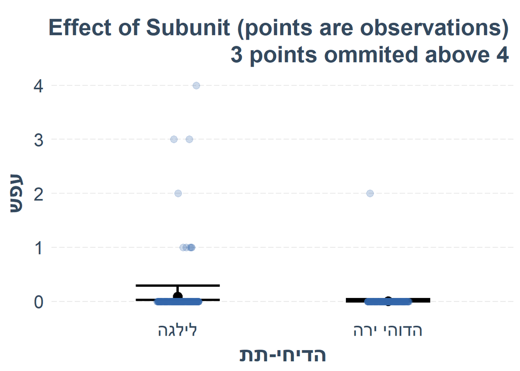

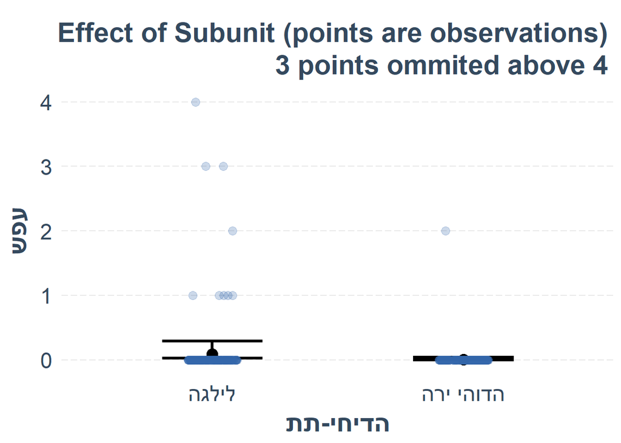

Compute predicted average difference in C. lupus abundance between Judea and Galilee based on model:

```
## [1] "C. lupus abundance in Galilee is higher than Judea by 2616.11505848146 %"
```

### Gazella gazella

```
##                  (Intercept) cosinus_Monitoring.Time.Diff
##                   -1.4415372                    0.2833693
##               SubunitGalilee                 SubunitJudea
##                    1.5479080                    2.3092798
```

```
##                              Canis.aureus Canis.lupus Gazella.gazella
## (Intercept)                    1.15639383  -15.265119      -1.4415371
## cosinus_Monitoring.Time.Diff  -0.01277888    2.349795       0.2833692
## SubunitGalilee                -0.23563268   13.135720       1.5479081
## SubunitJudea                  -0.65695209    9.833992       2.3092794
##                              Hyaena.hyaena Hystrix.indica Lepus.capensis
## (Intercept)                    -2.38932951     -0.1085528      -2.789939
## cosinus_Monitoring.Time.Diff    0.01226337     -0.2274492       1.545720
## SubunitGalilee                 -0.88707807     -0.4336437     -12.261799
## SubunitJudea                    0.13990694      0.7355202      -1.202820
##                              Meles.meles Sus.scrofa Vulpes.vulpes
## (Intercept)                   -1.5382238  1.4022934    0.13707508
## cosinus_Monitoring.Time.Diff  -0.6454851  0.3089406    0.21357692
## SubunitGalilee                -0.6794879  0.2706287    0.04402336
## SubunitJudea                  -1.2169837 -3.1504033    0.16147197
```

```
## [1] 658
```

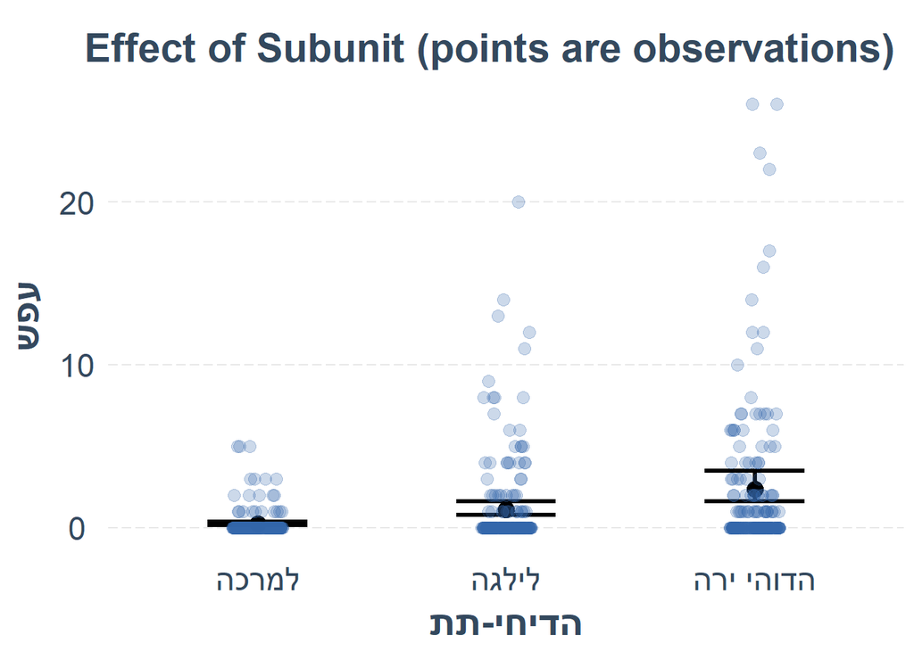

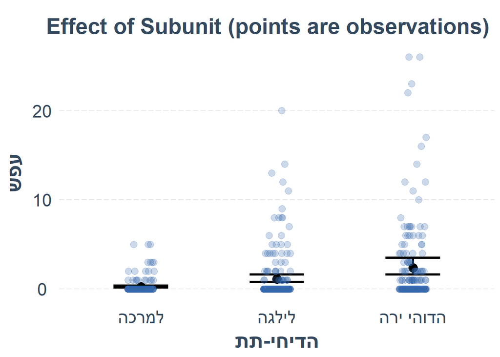

```
##  Subunit emmean    SE  df asymp.LCL asymp.UCL
##  Carmel  -1.445 0.233 Inf    -1.902    -0.989
##  Galilee  0.103 0.191 Inf    -0.272     0.477
##  Judea    0.864 0.193 Inf     0.485     1.243
##
## Results are given on the log (not the response) scale.
## Confidence level used: 0.95
```

```
##  contrast         estimate    SE  df z.ratio p.value
##  Carmel - Galilee   -1.548 0.297 Inf  -5.206  <.0001
##  Carmel - Judea     -2.309 0.310 Inf  -7.458  <.0001
##  Galilee - Judea    -0.761 0.278 Inf  -2.742  0.0061
##
## Results are given on the log (not the response) scale.
## P value adjustment: fdr method for 3 tests
```

Compute predicted average difference in G. gazella abundance among all subunits based on model:

```
## [1] "G. gazella abundance in Judea is higher than Carmel by 906.717136260408 %"
```

```
## [1] "G. gazella abundance in Judea is higher than Galilee by 114.121147912163 %"
```

```
## [1] "G. gazella abundance in Galilee is higher than Carmel by 370.162403889869 %"
```

### Hystrix indica

```
##                  (Intercept) cosinus_Monitoring.Time.Diff
##                   -0.1085528                   -0.2274502
##               SubunitGalilee                 SubunitJudea
##                   -0.4336430                    0.7355195
```

```
##                              Canis.aureus Canis.lupus Gazella.gazella
## (Intercept)                    1.15639383  -15.265119      -1.4415371
## cosinus_Monitoring.Time.Diff  -0.01277888    2.349795       0.2833692
## SubunitGalilee                -0.23563268   13.135720       1.5479081
## SubunitJudea                  -0.65695209    9.833992       2.3092794
##                              Hyaena.hyaena Hystrix.indica Lepus.capensis
## (Intercept)                    -2.38932951     -0.1085528      -2.789939
## cosinus_Monitoring.Time.Diff    0.01226337     -0.2274492       1.545720
## SubunitGalilee                 -0.88707807     -0.4336437     -12.261799
## SubunitJudea                    0.13990694      0.7355202      -1.202820
##                              Meles.meles Sus.scrofa Vulpes.vulpes
## (Intercept)                   -1.5382238  1.4022934    0.13707508
## cosinus_Monitoring.Time.Diff  -0.6454851  0.3089406    0.21357692
## SubunitGalilee                -0.6794879  0.2706287    0.04402336
## SubunitJudea                  -1.2169837 -3.1504033    0.16147197
```

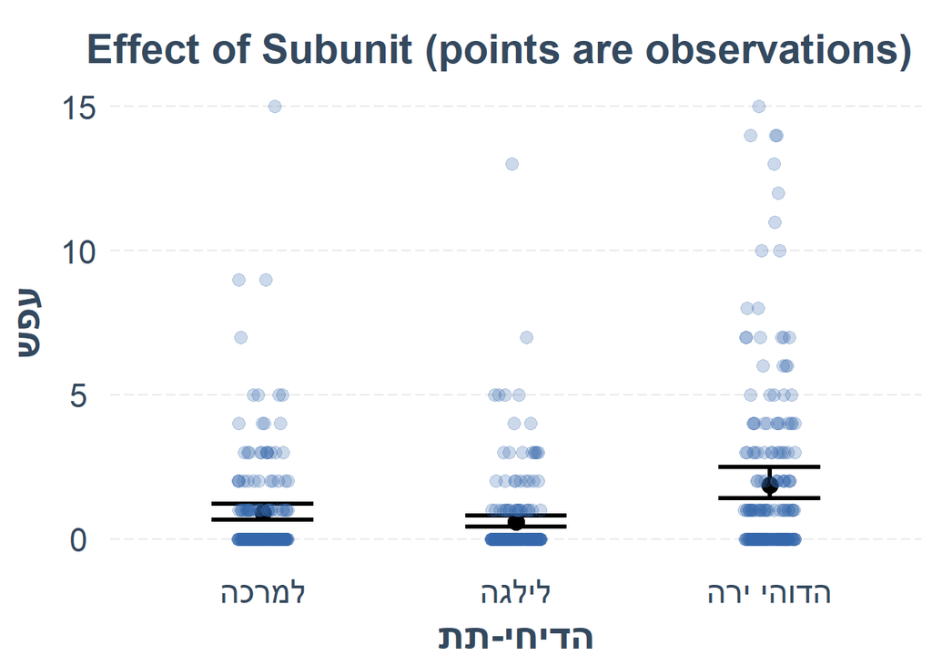

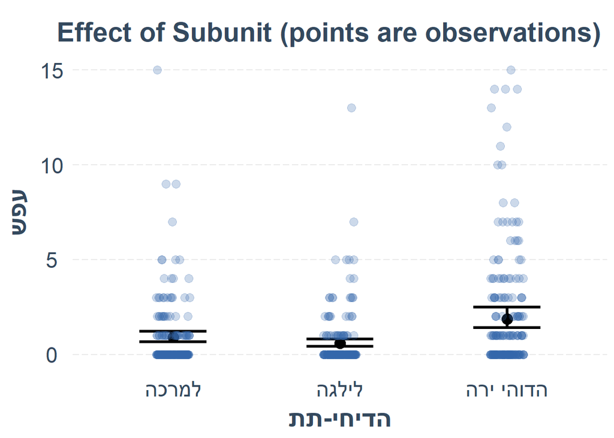

```
##  Subunit emmean    SE  df asymp.LCL asymp.UCL
##  Carmel  -0.106 0.150 Inf    -0.400     0.189
##  Galilee -0.539 0.161 Inf    -0.854    -0.224
##  Judea    0.630 0.145 Inf     0.345     0.915
##
## Results are given on the log (not the response) scale.
## Confidence level used: 0.95
```

```
##  contrast         estimate    SE  df z.ratio p.value
##  Carmel - Galilee    0.434 0.219 Inf   1.981  0.0476
##  Carmel - Judea     -0.736 0.213 Inf  -3.450  0.0008
##  Galilee - Judea    -1.169 0.220 Inf  -5.314  <.0001
##
## Results are given on the log (not the response) scale.
## P value adjustment: fdr method for 3 tests
```

Compute predicted average difference in H. indica abundance among all subunits based on model:

```
## [1] "H. indica abundance in Judea is higher than Carmel by 108.656566090016 %"
```

```
## [1] "H. indica abundance in Judea is higher than Galilee by 221.929523047567 %"
```

```
## [1] "H. indica abundance in Carmel is higher than Galilee by 54.286792445671 %"
```

### Lepus cepensis

remove Galilee observations because they are all zeros.

```
##
## Call:
## glm.nb(formula = Lepus.capensis ~ cosinus_Monitoring.Time.Diff +
##     Subunit, data = env_data[Subunit != "Galilee"], init.theta = 0.03079447589,
##     link = log)
##
## Coefficients:
##                              Estimate Std. Error z value Pr(>|z|)
## (Intercept)                   -2.7900     0.5638  -4.948 7.49e-07 ***
## cosinus_Monitoring.Time.Diff   1.5458     0.6681   2.314   0.0207 *
## SubunitJudea                  -1.2028     0.9361  -1.285   0.1988
## ---
## Signif. codes:  0 '***' 0.001 '**' 0.01 '*' 0.05 '.' 0.1 ' ' 1
##
## (Dispersion parameter for Negative Binomial(0.0308) family taken to be 1)
##
##     Null deviance: 43.181  on 365  degrees of freedom
## Residual deviance: 32.236  on 363  degrees of freedom
## AIC: 127.01
##
## Number of Fisher Scoring iterations: 1
##
##
##               Theta:  0.0308
##           Std. Err.:  0.0145
##
##  2 x log-likelihood:  -119.0130
```

After removing Galilee, subunit is not a significant factor on Lepus capensis abundance.

### Sus scrofa

although significant, exclude model because appears again later in model with subunit*time interaction.

## Many GLM with interaction between subunit and time

```
## Single term deletions
##
## Model:
## spp_no_rare ~ Subunit * rescaled_Time.Diff + cosinus_Monitoring.Time.Diff +
##     sinus_Monitoring.Time.Diff
##                              Df    AIC
## <none>                          9649.3
## cosinus_Monitoring.Time.Diff  9 9675.6
## sinus_Monitoring.Time.Diff    9 9651.3
## Subunit:rescaled_Time.Diff   18 9664.1
```

drop sine

```
## Single term deletions
##
## Model:
## spp_no_rare ~ Subunit * rescaled_Time.Diff + cosinus_Monitoring.Time.Diff
##                              Df    AIC
## <none>                          9651.3
## cosinus_Monitoring.Time.Diff  9 9681.0
## Subunit:rescaled_Time.Diff   18 9664.6
```

Final model includes cosin time, and the interaction between subunit and time

```
##
## Test statistics:
##                                   wald value Pr(>wald)
## (Intercept)                           19.897     0.001 ***
## SubunitGalilee                         6.900     0.001 ***
## SubunitJudea                          13.712     0.001 ***
## rescaled_Time.Diff                     4.659     0.018 *
## cosinus_Monitoring.Time.Diff           7.041     0.001 ***
## SubunitGalilee:rescaled_Time.Diff      3.729     0.095 .
## SubunitJudea:rescaled_Time.Diff        5.697     0.002 **
## ---
## Signif. codes:  0 '***' 0.001 '**' 0.01 '*' 0.05 '.' 0.1 ' ' 1
##
## Test statistic:  19.43, p-value: 0.001
## Arguments:
##  Test statistics calculated assuming response assumed to be uncorrelated
##  P-value calculated using 999 resampling iterations via pit.trap resampling (to account for correlation in testing).
```

```
## Analysis of Deviance Table
##
## Model: spp_no_rare ~ Subunit * rescaled_Time.Diff + cosinus_Monitoring.Time.Diff
##
## Multivariate test:
##                              Res.Df Df.diff   Dev Pr(>Dev)
## (Intercept)                     550
## Subunit                         548       2 397.8    0.001 ***
## rescaled_Time.Diff              547       1  28.7    0.005 **
## cosinus_Monitoring.Time.Diff    546       1  40.9    0.001 ***
## Subunit:rescaled_Time.Diff      544       2  49.3    0.001 ***
## ---
## Signif. codes:  0 '***' 0.001 '**' 0.01 '*' 0.05 '.' 0.1 ' ' 1
##
## Univariate Tests:
##                              Canis.aureus          Canis.lupus
##                                       Dev Pr(>Dev)         Dev Pr(>Dev)
## (Intercept)
## Subunit                            10.799    0.041      20.911    0.002
## rescaled_Time.Diff                   1.08    0.720       3.385    0.403
## cosinus_Monitoring.Time.Diff        0.066    0.921      10.384    0.029
## Subunit:rescaled_Time.Diff         10.124    0.047       0.828    0.750
##                              Gazella.gazella          Hyaena.hyaena
##                                          Dev Pr(>Dev)           Dev Pr(>Dev)
## (Intercept)
## Subunit                               45.182    0.001         5.049    0.312
## rescaled_Time.Diff                     0.168    0.720         6.355    0.118
## cosinus_Monitoring.Time.Diff           3.583    0.280         0.147    0.921
## Subunit:rescaled_Time.Diff             5.377    0.347         2.992    0.714
##                              Hystrix.indica          Lepus.capensis
##                                         Dev Pr(>Dev)            Dev Pr(>Dev)
## (Intercept)
## Subunit                              35.944    0.001         12.792    0.020
## rescaled_Time.Diff                    2.088    0.653          0.995    0.720
## cosinus_Monitoring.Time.Diff          3.121    0.280          4.454    0.201
## Subunit:rescaled_Time.Diff            2.935    0.714          0.658    0.750
##                              Meles.meles          Sus.scrofa
##                                      Dev Pr(>Dev)        Dev Pr(>Dev)
## (Intercept)
## Subunit                            4.537    0.312    262.411    0.001
## rescaled_Time.Diff                 1.242    0.720      11.33    0.023
## cosinus_Monitoring.Time.Diff       6.278    0.103      9.464    0.040
## Subunit:rescaled_Time.Diff         1.194    0.750     23.219    0.002
##                              Vulpes.vulpes
##                                        Dev Pr(>Dev)
## (Intercept)
## Subunit                              0.172    0.927
## rescaled_Time.Diff                   2.073    0.653
## cosinus_Monitoring.Time.Diff         3.377    0.280
## Subunit:rescaled_Time.Diff           1.961    0.750
## Arguments:
##  Test statistics calculated assuming uncorrelated response (for faster computation)
## P-value calculated using 999 iterations via PIT-trap resampling.
```

**Multivariate test shows that subunit x time and cosin time affect species composition**

[output not shown]

### Sus scrofa

```
##                       (Intercept)                    SubunitGalilee
##                        1.41055124                        0.26258260
##                      SubunitJudea                rescaled_Time.Diff
##                       -3.73253998                        0.03934223
##      cosinus_Monitoring.Time.Diff SubunitGalilee:rescaled_Time.Diff
##                        0.37166673                        0.15529898
##   SubunitJudea:rescaled_Time.Diff
##                        1.60040468
```

```
##                                   Canis.aureus Canis.lupus Gazella.gazella
## (Intercept)                         0.92543101 -15.4308536      -1.8332971
## SubunitGalilee                     -0.03074436  12.6432995       1.8857368
## SubunitJudea                       -0.36640001  -2.2782729       2.7685771
## rescaled_Time.Diff                 -0.42047111  -0.5434586      -0.7183219
## cosinus_Monitoring.Time.Diff        0.09945115   2.4821167       0.4126787
## SubunitGalilee:rescaled_Time.Diff   0.43345435  -0.3680742       0.5778458
## SubunitJudea:rescaled_Time.Diff     0.61366644  -7.8694219       0.8264836
##                                   Hyaena.hyaena Hystrix.indica Lepus.capensis
## (Intercept)                          -2.3908425    -0.06936227     -3.4165292
## SubunitGalilee                       -1.3611449    -0.47199689    -11.7373210
## SubunitJudea                          0.1675971     0.68651809     -0.4949739
## rescaled_Time.Diff                    0.1818044     0.15367707     -0.7543741
## cosinus_Monitoring.Time.Diff          0.1975235    -0.22235591      2.0190428
## SubunitGalilee:rescaled_Time.Diff     1.0969510     0.13600423      0.9141765
## SubunitJudea:rescaled_Time.Diff       0.4022983    -0.22366184      0.9937627
##                                   Meles.meles Sus.scrofa Vulpes.vulpes
## (Intercept)                       -1.46354722  1.4105503    0.06199016
## SubunitGalilee                    -0.77235943  0.2625836    0.12571886
## SubunitJudea                      -1.34887689 -3.7325367    0.22039441
## rescaled_Time.Diff                 0.32320482  0.0393417   -0.19055860
## cosinus_Monitoring.Time.Diff      -0.70482555  0.3716676    0.22892562
## SubunitGalilee:rescaled_Time.Diff -0.42232025  0.1552999    0.25459349
## SubunitJudea:rescaled_Time.Diff   -0.08611442  1.6004043    0.09657084
```

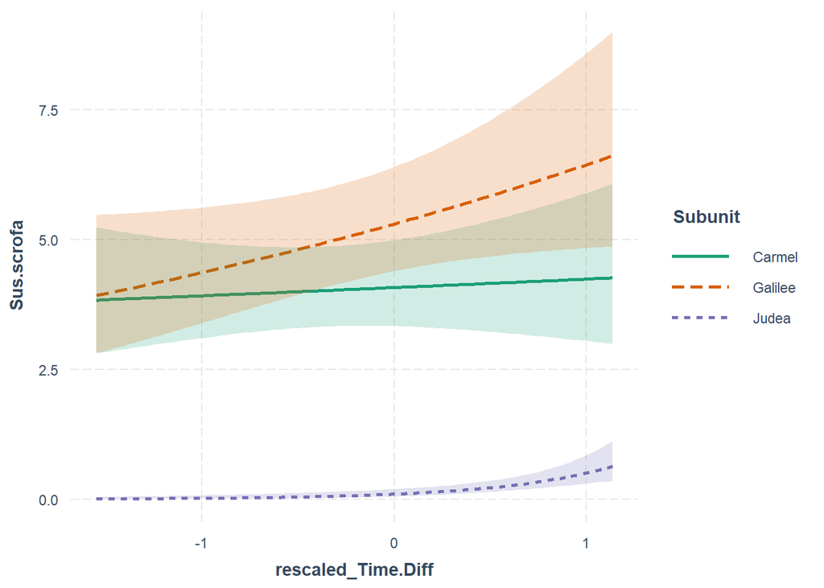

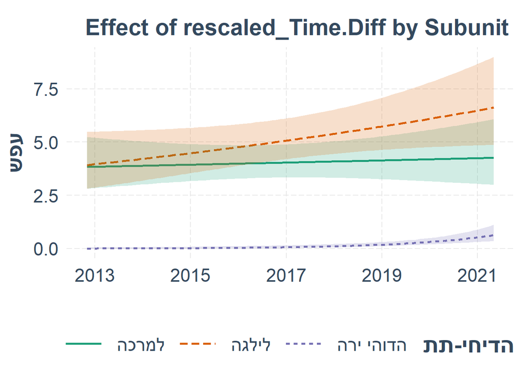

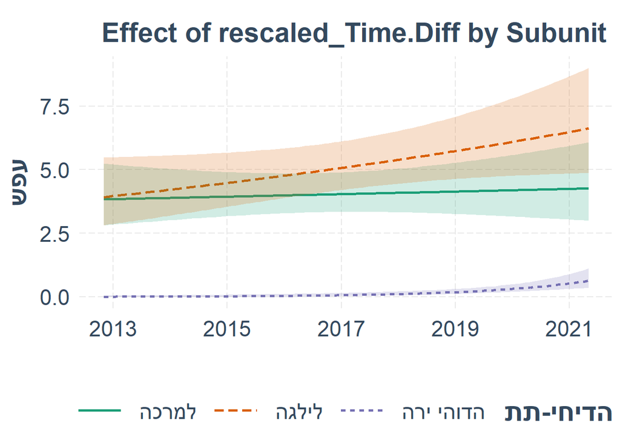

Test whether temporal trend is different from zero

```
##  Subunit rescaled_Time.Diff.trend     SE  df asymp.LCL asymp.UCL
##  Carmel                    0.0393 0.1031 Inf  -0.16264     0.241
##  Galilee                   0.1946 0.0986 Inf   0.00135     0.388
##  Judea                     1.6397 0.3869 Inf   0.88150     2.398
##
## Confidence level used: 0.95
```

```
##  Subunit rescaled_Time.Diff.trend     SE  df z.ratio p.value
##  Carmel                    0.0393 0.1031 Inf   0.382  0.7026
##  Galilee                   0.1946 0.0986 Inf   1.974  0.0726
##  Judea                     1.6397 0.3869 Inf   4.238  0.0001
##
## P value adjustment: fdr method for 3 tests
```

```
## [1] "start date: 02/06/2013"
```

```
## [1] "end date: 04/12/2021"
```

```
## [1] "Increase from 0.010218826979616 to 0.834094255411373 which is 8062.32877878432 %"
```

Test whether spatial differences in subunit are different from zero

```
##  contrast         rescaled_Time.Diff estimate    SE  df z.ratio p.value
##  Carmel - Galilee             -0.201   -0.231 0.133 Inf  -1.734  0.0829
##  Carmel - Judea               -0.201    4.055 0.420 Inf   9.653  <.0001
##  Galilee - Judea              -0.201    4.286 0.419 Inf  10.221  <.0001
##
## Results are given on the log (not the response) scale.
## P value adjustment: fdr method for 3 tests
```

Compute predicted average difference in S. scrofa abundance between Judea-Carmel and Judea-Galilee based on model:

```
## [1] "S. scrofa abundance in Carmel is higher than Judea by 5707.2598683446 %"
```

```
## [1] "S. scrofa abundance in Galilee is higher than Judea by 7213.71399264225 %"
```

### Canis aureus

```
##                       (Intercept)                    SubunitGalilee
##                        0.92543131                       -0.03074468
##                      SubunitJudea                rescaled_Time.Diff
##                       -0.36640052                       -0.42047027
##      cosinus_Monitoring.Time.Diff SubunitGalilee:rescaled_Time.Diff
##                        0.09945076                        0.43345366
##   SubunitJudea:rescaled_Time.Diff
##                        0.61366445
```

```
##                                   Canis.aureus Canis.lupus Gazella.gazella
## (Intercept)                         0.92543101 -15.4308536      -1.8332971
## SubunitGalilee                     -0.03074436  12.6432995       1.8857368
## SubunitJudea                       -0.36640001  -2.2782729       2.7685771
## rescaled_Time.Diff                 -0.42047111  -0.5434586      -0.7183219
## cosinus_Monitoring.Time.Diff        0.09945115   2.4821167       0.4126787
## SubunitGalilee:rescaled_Time.Diff   0.43345435  -0.3680742       0.5778458
## SubunitJudea:rescaled_Time.Diff     0.61366644  -7.8694219       0.8264836
##                                   Hyaena.hyaena Hystrix.indica Lepus.capensis
## (Intercept)                          -2.3908425    -0.06936227     -3.4165292
## SubunitGalilee                       -1.3611449    -0.47199689    -11.7373210
## SubunitJudea                          0.1675971     0.68651809     -0.4949739
## rescaled_Time.Diff                    0.1818044     0.15367707     -0.7543741
## cosinus_Monitoring.Time.Diff          0.1975235    -0.22235591      2.0190428
## SubunitGalilee:rescaled_Time.Diff     1.0969510     0.13600423      0.9141765
## SubunitJudea:rescaled_Time.Diff       0.4022983    -0.22366184      0.9937627
##                                   Meles.meles Sus.scrofa Vulpes.vulpes
## (Intercept)                       -1.46354722  1.4105503    0.06199016
## SubunitGalilee                    -0.77235943  0.2625836    0.12571886
## SubunitJudea                      -1.34887689 -3.7325367    0.22039441
## rescaled_Time.Diff                 0.32320482  0.0393417   -0.19055860
## cosinus_Monitoring.Time.Diff      -0.70482555  0.3716676    0.22892562
## SubunitGalilee:rescaled_Time.Diff -0.42232025  0.1552999    0.25459349
## SubunitJudea:rescaled_Time.Diff   -0.08611442  1.6004043    0.09657084
```

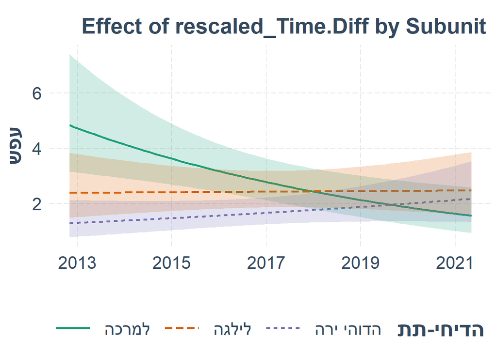

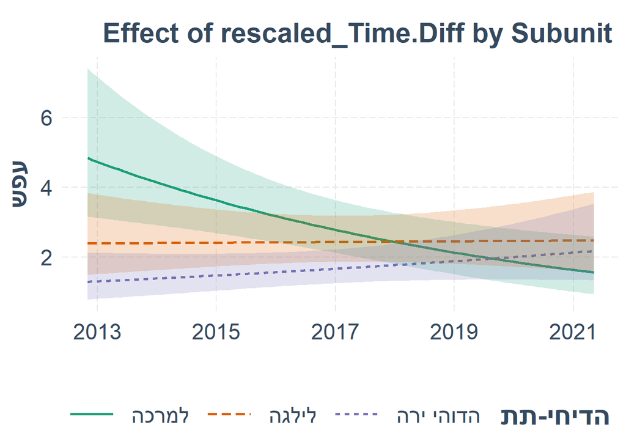

Test whether temporal trend is different from zero

```
## [1] "Canis aureus"
```

```
##  Subunit rescaled_Time.Diff.trend    SE  df asymp.LCL asymp.UCL
##  Carmel                    -0.420 0.144 Inf    -0.704    -0.137
##  Galilee                    0.013 0.141 Inf    -0.264     0.290
##  Judea                      0.193 0.151 Inf    -0.103     0.490
##
## Confidence level used: 0.95
```

```
##  Subunit rescaled_Time.Diff.trend    SE  df z.ratio p.value
##  Carmel                    -0.420 0.144 Inf  -2.911  0.0108
##  Galilee                    0.013 0.141 Inf   0.092  0.9267
##  Judea                      0.193 0.151 Inf   1.278  0.3021
##
## P value adjustment: fdr method for 3 tests
```

Compute predicted decrease in C. aureus across monitoring time span based on model:

```
## [1] "start date: 02/06/2013"
```

```
## [1] "end date: 04/12/2021"
```

```
## [1] "Decrease from 5.20890920835607 to 1.68465894204887 which is -67.6581242893165 %"
```

Test whether spatial differences in subunit are different from zero

```
##  contrast         rescaled_Time.Diff estimate    SE  df z.ratio p.value
##  Carmel - Galilee             -0.201    0.118 0.190 Inf   0.621  0.5349
##  Carmel - Judea               -0.201    0.490 0.205 Inf   2.395  0.0499
##  Galilee - Judea              -0.201    0.372 0.203 Inf   1.834  0.1000
##
## Results are given on the log (not the response) scale.
## P value adjustment: fdr method for 3 tests
```

Compute predicted average difference in C. aureus abundance between Carmel and Judea based on model:

```
## [1] "C. aureus abundance in Carmel is higher than Judea by 63.6586044456966 %"
```

n = 551 (total number of cameras)

total abundance = 5613 (9 species), total abundance without rare species is the same